# week11_hw

파라미터는 minsplit = 5, minbucket = 3, maxdepth = 15, cp_ = 0.002로 설정

```r
tree<-make_tree(tree_data, minsplit = 5, minbucket = 3, maxdepth = 15, cp_ = 0.002)
```

```
## [1] 55.40605
```

```r
#pdf("tree.pdf")
#fancyRpartPlot(tree)
#dev.off()
```

plot 으로 확인

[figure not shown]

```r
windows()

fancyRpartPlot(tree)
```

```r
#dev.off()
```

결과 고찰

트리를 분할한 예측 변수로는 인간관계, 계층의식, 소득, 생활수준 변화, 기부경험이 있다

‘만족감= 만족’ 을 기준으로 볼때, 인간관계가 만족하면서 계층의식이 상류층 혹은 중산층인 경우 삶에 만족하며 또는 인간관계는 보통이더라도 계층의식이 높으며 소득수준에 만족하고 기부경험이 있을때, 삶에 만족한다.

즉, 삶에 만족하는 데 가장 중요한 것은 소득 수준과 인간관계라고 할수 있다.

‘만족감 =보통’ 을 기준으로 볼때, 인간관계가 만족하면서 계층의식이 낮은 경우/ 인간관계는 보통이지만 소득에 만족하는 경우/ 인간관계가 보통이며,계층 의식은 낮지만, 생활수준의 변화가 있는 경우 삶을 보통수준이라고 생각한다

’만족감 = 불만족’을 기준으로 볼때, 인간관계가 보통혹은 나쁘거나 생활수준의 변화가 안좋아진 경우 삶에 불만족한다.

변수의 독립성 확인

트리데이터와 rules를 통해 보았을때, 전체적인 소득수준과 인간관계가 삶의 만족도를 결정하는 주요 변수 처럼 보임 따라서 계층의식과 인간관계를 선정하여 독립성을 확인인

상류층의 경우 인간관계 만족감이 높으나 빈곤층일지라도 불만족 보다는 보통이 더 많음 인간관계의 경우 선형관계가 성립하는데 인간관계의 만족도가 높을수록 삶의 만족도도 비례적으로 높음

```r
table(social$계층의식,social$만족감)
```

```
##
##          만족 보통 불만족
##   빈곤층 2459 6657   4987
##   상류층  679  169     75
##   중산층 9369 9078   2950
```

```r
table(social$인간관계,social$만족감)
```

```
##
##          만족 보통 불만족
##   만족   9582 6807   2668
##   보통   2713 8546   4199
##   불만족  212  551   1145
```

독립성 테스트 결과 h0(귀무 가설): 게층의식, 인간관계는 만족감과 연관이 없다 h1(연구 가설): 게층의식, 인간관계는 만족감과 연관이 있다 둘의 p-value가 2.2e-16 임으로 귀무가설을 기각 즉, 계층의식과 인간관계는 만족감과 연관이 있으며, 종속적이다.

```r
chisq.test(social$계층의식,social$만족감)
```

```
##
##  Pearson's Chi-squared test
##
## data:  social$계층의식 and social$만족감
## X-squared = 4208.5, df = 4, p-value < 2.2e-16
```

```r
chisq.test(social$인간관계,social$만족감)
```

```
##
##  Pearson's Chi-squared test
##
## data:  social$인간관계 and social$만족감
## X-squared = 5823.1, df = 4, p-value < 2.2e-16
```

#트리데이터의 결과와 rulse 비교

’만족감 = 만족’의 경우 tree데이터와 rules의 상위 결과가 거의 일치한다

인간관게=만족, 소득수준=중산층 이상

다만 트리데이터에서는 혼인 상태에 관한 결과는 없었지만 rules를 통해서 보았을때, 신뢰도와 향상도 기준모두 혼인상태가 기혼인 경우 삶에대한 만족감이 만족인 경우 가 더 많음을 나타낸다

```r
rules_conf_1 <- sort (rules_1, by="confidence", decreasing=TRUE)
inspect(head(rules_conf_1,5))
```

```
##     lhs                            rhs              support confidence   coverage     lift count
## [1] {기억.집중.가능.여부=가능,
##      자기개발.가능여부=가능,
##      인간관계=만족,
##      계층의식=중산층,
##      소득.만족도=만족,
##      혼인상태=기혼}             => {만족감=만족} 0.05197265  0.7317356 0.07102655 2.130967  1893
## [2] {기억.집중.가능.여부=가능,
##      인간관계=만족,
##      계층의식=중산층,
##      소득.만족도=만족,
##      혼인상태=기혼}             => {만족감=만족} 0.05208248  0.7298961 0.07135601 2.125610  1897
## [3] {자기개발.가능여부=가능,
##      인간관계=만족,
##      계층의식=중산층,
##      소득.만족도=만족,
##      혼인상태=기혼}             => {만족감=만족} 0.05691459  0.7276237 0.07821981 2.118992  2073
## [4] {인간관계=만족,
##      계층의식=중산층,
##      소득.만족도=만족,
##      혼인상태=기혼}             => {만족감=만족} 0.05732641  0.7250000 0.07907092 2.111352  2088
## [5] {기억.집중.가능.여부=가능,
##      자기개발.가능여부=가능,
##      인간관계=만족,
##      소득.만족도=만족,
##      혼인상태=기혼}             => {만족감=만족} 0.06284491  0.7202643 0.08725256 2.097560  2289
```

```r
rules_conf_1 <- sort (rules_1, by="lift", decreasing=TRUE)
inspect(head(rules_conf_1,5))
```

```
##     lhs                            rhs              support confidence   coverage     lift count
## [1] {기억.집중.가능.여부=가능,
##      자기개발.가능여부=가능,
##      인간관계=만족,
##      계층의식=중산층,
##      소득.만족도=만족,
##      혼인상태=기혼}             => {만족감=만족} 0.05197265  0.7317356 0.07102655 2.130967  1893
## [2] {기억.집중.가능.여부=가능,
##      인간관계=만족,
##      계층의식=중산층,
##      소득.만족도=만족,
##      혼인상태=기혼}             => {만족감=만족} 0.05208248  0.7298961 0.07135601 2.125610  1897
## [3] {자기개발.가능여부=가능,
##      인간관계=만족,
##      계층의식=중산층,
##      소득.만족도=만족,
##      혼인상태=기혼}             => {만족감=만족} 0.05691459  0.7276237 0.07821981 2.118992  2073
## [4] {인간관계=만족,
##      계층의식=중산층,
##      소득.만족도=만족,
##      혼인상태=기혼}             => {만족감=만족} 0.05732641  0.7250000 0.07907092 2.111352  2088
## [5] {기억.집중.가능.여부=가능,
##      자기개발.가능여부=가능,
##      인간관계=만족,
##      소득.만족도=만족,
##      혼인상태=기혼}             => {만족감=만족} 0.06284491  0.7202643 0.08725256 2.097560  2289
```

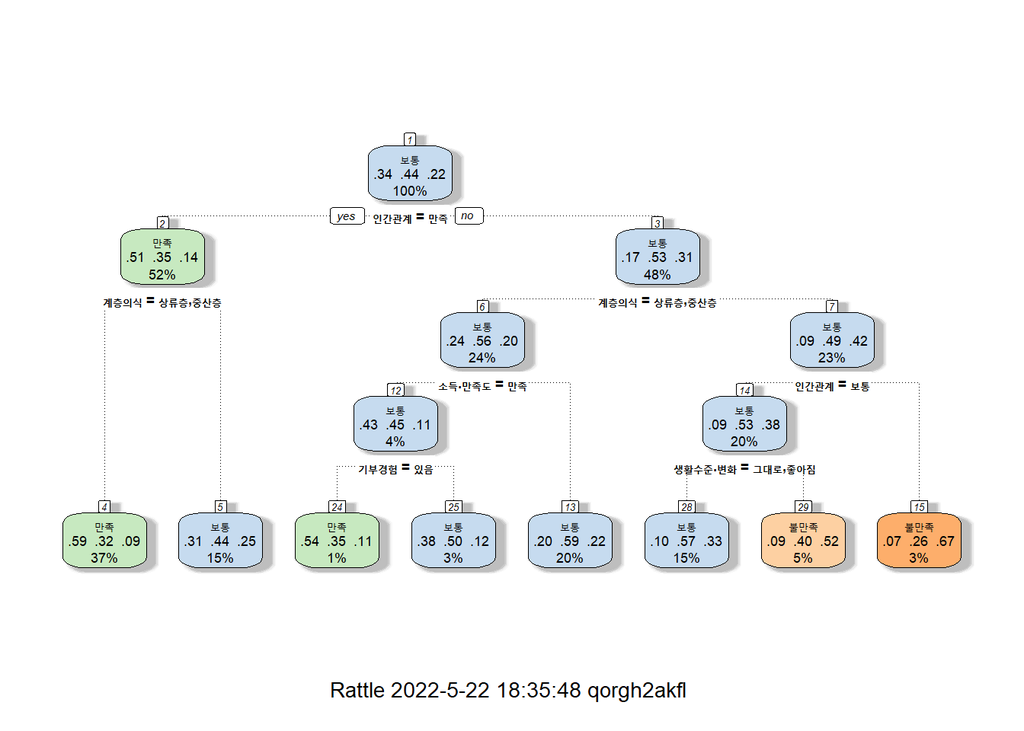

```r
fancyRpartPlot(tree)
```

‘만족감=보통’ 인경우 역시 트리데이터와 비슷하다

인간관계와 소득수준이 보통인 경우 주로 삶에 만족수준이 보통임을 알 수 있다. rules를 통해서 기부경험이 없을 수록 삶의 만족도가 보통임을 알수 있다.

```r
rules_conf_2 <- sort (rules_2, by="confidence", decreasing=TRUE)
inspect(head(rules_conf_2,5))
```

```
##     lhs                            rhs              support confidence   coverage     lift count
## [1] {기억.집중.가능.여부=가능,
##      자기개발.가능여부=가능,
##      생활수준.변화=그대로,
##      인간관계=보통,
##      기부경험=없음,
##      소득.만족도=보통}          => {만족감=보통} 0.05491036  0.6613757 0.08302446 1.514668  2000
## [2] {기억.집중.가능.여부=가능,
##      생활수준.변화=그대로,
##      인간관계=보통,
##      기부경험=없음,
##      소득.만족도=보통}          => {만족감=보통} 0.05545946  0.6599151 0.08404030 1.511323  2020
## [3] {자기개발.가능여부=가능,
##      생활수준.변화=그대로,
##      인간관계=보통,
##      기부경험=없음,
##      소득.만족도=보통}          => {만족감=보통} 0.06067595  0.6571514 0.09233177 1.504994  2210
## [4] {기억.집중.가능.여부=가능,
##      자기개발.가능여부=가능,
##      생활수준.변화=그대로,
##      인간관계=보통,
##      소득.만족도=보통}          => {만족감=보통} 0.06166433  0.6527172 0.09447327 1.494839  2246
## [5] {생활수준.변화=그대로,
##      인간관계=보통,
##      기부경험=없음,
##      소득.만족도=보통}          => {만족감=보통} 0.06438240  0.6519322 0.09875628 1.493041  2345
```

```r
rules_conf_2 <- sort (rules_2, by="lift", decreasing=TRUE)
inspect(head(rules_conf_2,5))
```

```
##     lhs                            rhs              support confidence   coverage     lift count
## [1] {기억.집중.가능.여부=가능,
##      자기개발.가능여부=가능,
##      생활수준.변화=그대로,
##      인간관계=보통,
##      기부경험=없음,
##      소득.만족도=보통}          => {만족감=보통} 0.05491036  0.6613757 0.08302446 1.514668  2000
## [2] {기억.집중.가능.여부=가능,
##      생활수준.변화=그대로,
##      인간관계=보통,
##      기부경험=없음,
##      소득.만족도=보통}          => {만족감=보통} 0.05545946  0.6599151 0.08404030 1.511323  2020
## [3] {자기개발.가능여부=가능,
##      생활수준.변화=그대로,
##      인간관계=보통,
##      기부경험=없음,
##      소득.만족도=보통}          => {만족감=보통} 0.06067595  0.6571514 0.09233177 1.504994  2210
## [4] {기억.집중.가능.여부=가능,
##      자기개발.가능여부=가능,
##      생활수준.변화=그대로,
##      인간관계=보통,
##      소득.만족도=보통}          => {만족감=보통} 0.06166433  0.6527172 0.09447327 1.494839  2246
## [5] {생활수준.변화=그대로,
##      인간관계=보통,
##      기부경험=없음,
##      소득.만족도=보통}          => {만족감=보통} 0.06438240  0.6519322 0.09875628 1.493041  2345
```

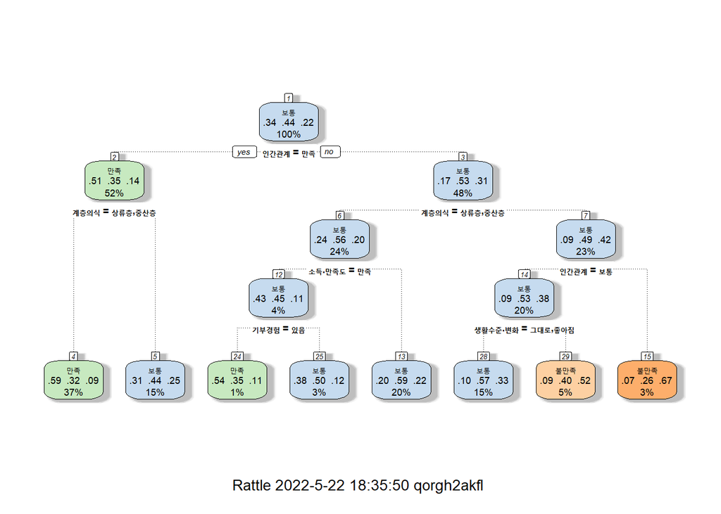

```r
fancyRpartPlot(tree)
```

’만족도 = 불만족’의 경우 트리데이터와 비교하면 rules를 통해 전체적인 소득 수준이 낮을때, 삶에 불만족함을 알수 있다.

```r
rules_conf_3 <- sort (rules_3, by="confidence", decreasing=TRUE)
inspect(head(rules_conf_3,5))
```

```
##     lhs                            rhs                support confidence  coverage     lift count
## [1] {기부경험=없음,
##      계층의식=빈곤층,
##      소득.만족도=불만족}        => {만족감=불만족} 0.07396425  0.4540705 0.1628916 2.064230  2694
## [2] {계층의식=빈곤층,
##      소득.만족도=불만족}        => {만족감=불만족} 0.08327156  0.4487350 0.1855696 2.039974  3033
## [3] {자기개발.가능여부=가능,
##      기부경험=없음,
##      계층의식=빈곤층,
##      소득.만족도=불만족}        => {만족감=불만족} 0.06561788  0.4429207 0.1481481 2.013542  2390
## [4] {자기개발.가능여부=가능,
##      계층의식=빈곤층,
##      소득.만족도=불만족}        => {만족감=불만족} 0.07432117  0.4374596 0.1698927 1.988716  2707
## [5] {기억.집중.가능.여부=가능,
##      기부경험=없음,
##      계층의식=빈곤층,
##      소득.만족도=불만족}        => {만족감=불만족} 0.05378470  0.4331196 0.1241798 1.968986  1959
```

```r
rules_conf_3 <- sort (rules_3, by="lift", decreasing=TRUE)
inspect(head(rules_conf_3,5))
```

```
##     lhs                            rhs                support confidence  coverage     lift count
## [1] {기부경험=없음,
##      계층의식=빈곤층,
##      소득.만족도=불만족}        => {만족감=불만족} 0.07396425  0.4540705 0.1628916 2.064230  2694
## [2] {계층의식=빈곤층,
##      소득.만족도=불만족}        => {만족감=불만족} 0.08327156  0.4487350 0.1855696 2.039974  3033
## [3] {자기개발.가능여부=가능,
##      기부경험=없음,
##      계층의식=빈곤층,
##      소득.만족도=불만족}        => {만족감=불만족} 0.06561788  0.4429207 0.1481481 2.013542  2390
## [4] {자기개발.가능여부=가능,
##      계층의식=빈곤층,
##      소득.만족도=불만족}        => {만족감=불만족} 0.07432117  0.4374596 0.1698927 1.988716  2707
## [5] {기억.집중.가능.여부=가능,
##      기부경험=없음,
##      계층의식=빈곤층,
##      소득.만족도=불만족}        => {만족감=불만족} 0.05378470  0.4331196 0.1241798 1.968986  1959
```

#기부경험에 따른 차이를 확인해보기위해 신뢰도 기준으로 각각 조사 - 만족과 보통을 나누는 차이를 구분해보고자

기부경험과 교육정도가 연관도가 높은것을 알 수 있음

```r
rules_d <- apriori (data=social_transaction,
                    parameter=list (supp=0.05,
                                    conf = 0.3
                    ),
                    appearance = list (default="lhs",
                                       rhs="기부경험=있음"))
```

```
## Apriori
##
## Parameter specification:
##  confidence minval smax arem  aval originalSupport maxtime support minlen
##         0.3    0.1    1 none FALSE            TRUE       5    0.05      1
##  maxlen target  ext
##      10  rules TRUE
##
## Algorithmic control:
##  filter tree heap memopt load sort verbose
##     0.1 TRUE TRUE  FALSE TRUE    2    TRUE
##
## Absolute minimum support count: 1821
##
## set item appearances ...[1 item(s)] done [0.00s].
## set transactions ...[34 item(s), 36423 transaction(s)] done [0.03s].
## sorting and recoding items ... [28 item(s)] done [0.00s].
## creating transaction tree ... done [0.02s].
## checking subsets of size 1 2 3 4 5 6 7 done [0.03s].
## writing ... [66 rule(s)] done [0.00s].
## creating S4 object  ... done [0.01s].
```

```r
#control = list (verbose=F))

rules_conf_d <- sort (rules_d, by="confidence", decreasing=TRUE)
inspect(head(rules_conf_d,5))
```

```
##     lhs                          rhs                support confidence  coverage     lift count
## [1] {자기개발.가능여부=가능,
##      계층의식=중산층,
##      교육정도=4년제,
##      혼인상태=기혼}           => {기부경험=있음} 0.05383961  0.4217204 0.1276666 1.993294  1961
## [2] {계층의식=중산층,
##      교육정도=4년제,
##      혼인상태=기혼}           => {기부경험=있음} 0.05427889  0.4208174 0.1289844 1.989026  1977
## [3] {만족감=만족,
##      자기개발.가능여부=가능,
##      교육정도=4년제}          => {기부경험=있음} 0.05070972  0.4131991 0.1227247 1.953017  1847
## [4] {만족감=만족,
##      교육정도=4년제}          => {기부경험=있음} 0.05098427  0.4128502 0.1234934 1.951368  1857
## [5] {자기개발.가능여부=가능,
##      교육정도=4년제,
##      혼인상태=기혼}           => {기부경험=있음} 0.06564533  0.4108247 0.1597891 1.941795  2391
```

```r
rules_dx <- apriori (data=social_transaction,
                    parameter=list (supp=0.05,
                                    conf = 0.3
                    ),
                    appearance = list (default="lhs",
                                       rhs="기부경험=없음"))
```

```
## Apriori
##
## Parameter specification:
##  confidence minval smax arem  aval originalSupport maxtime support minlen
##         0.3    0.1    1 none FALSE            TRUE       5    0.05      1
##  maxlen target  ext
##      10  rules TRUE
##
## Algorithmic control:
##  filter tree heap memopt load sort verbose
##     0.1 TRUE TRUE  FALSE TRUE    2    TRUE
##
## Absolute minimum support count: 1821
##
## set item appearances ...[1 item(s)] done [0.00s].
## set transactions ...[34 item(s), 36423 transaction(s)] done [0.04s].
## sorting and recoding items ... [28 item(s)] done [0.00s].
## creating transaction tree ... done [0.02s].
## checking subsets of size 1 2 3 4 5 6 7 done [0.02s].
## writing ... [1163 rule(s)] done [0.00s].
## creating S4 object  ... done [0.00s].
```

```r
#control = list (verbose=F))

rules_conf_dx <- sort (rules_dx, by="confidence", decreasing=TRUE)
inspect(head(rules_conf_dx,5))
```

```
##     lhs
## [1] {계층의식=빈곤층, 교육정도=초등학교}                                  =>
## [2] {기억.집중.가능.여부=가능, 자기개발.가능여부=가능, 교육정도=초등학교} =>
## [3] {기억.집중.가능.여부=가능, 교육정도=초등학교}                         =>
## [4] {계층의식=빈곤층, 혼인상태=별거}                                      =>
## [5] {교육정도=초등학교}                                                   =>
##     rhs             support    confidence coverage   lift     count
## [1] {기부경험=없음} 0.05765588 0.9417040  0.06122505 1.194404 2100
## [2] {기부경험=없음} 0.05878154 0.9276430  0.06336655 1.176569 2141
## [3] {기부경험=없음} 0.06100541 0.9266055  0.06583752 1.175253 2222
## [4] {기부경험=없음} 0.05200011 0.9234520  0.05631057 1.171254 1894
## [5] {기부경험=없음} 0.09123356 0.9207537  0.09908574 1.167831 3323
```

# 교육수준에 따른 rules조사

- 교육수준이 인간관계나 소득수준에 영향을 미치는 지 측정하기위해 조사

교육수준이 4년제인 경우 경제적으로는 중산층일지라도 기부경험이 높으며 만족감이 높음 교육수준이 초등학교인 경우 소득 수준이 낮으며, 가정환경이 좋지 않음

```r
rules_e <- apriori (data=social_transaction,
                    parameter=list (supp=0.05,
                                    conf = 0.3
                    ),
                    appearance = list (default="lhs",
                                       rhs="교육정도=4년제"))
```

```
## Apriori
##
## Parameter specification:
##  confidence minval smax arem  aval originalSupport maxtime support minlen
##         0.3    0.1    1 none FALSE            TRUE       5    0.05      1
##  maxlen target  ext
##      10  rules TRUE
##
## Algorithmic control:
##  filter tree heap memopt load sort verbose
##     0.1 TRUE TRUE  FALSE TRUE    2    TRUE
##
## Absolute minimum support count: 1821
##
## set item appearances ...[1 item(s)] done [0.00s].
## set transactions ...[34 item(s), 36423 transaction(s)] done [0.02s].
## sorting and recoding items ... [28 item(s)] done [0.00s].
## creating transaction tree ... done [0.02s].
## checking subsets of size 1 2 3 4 5 6 7 done [0.03s].
## writing ... [170 rule(s)] done [0.00s].
## creating S4 object  ... done [0.01s].
```

```r
#control = list (verbose=F))

rules_conf_e <- sort (rules_e, by="confidence", decreasing=TRUE)
inspect(head(rules_conf_e,5))
```

```
##     lhs                            rhs                 support confidence  coverage     lift count
## [1] {만족감=만족,
##      자기개발.가능여부=가능,
##      기부경험=있음}             => {교육정도=4년제} 0.05070972  0.4985155 0.1017214 1.830940  1847
## [2] {만족감=만족,
##      기부경험=있음}             => {교육정도=4년제} 0.05098427  0.4955965 0.1028746 1.820219  1857
## [3] {기억.집중.가능.여부=가능,
##      자기개발.가능여부=가능,
##      기부경험=있음,
##      계층의식=중산층}           => {교육정도=4년제} 0.06279000  0.4807652 0.1306043 1.765747  2287
## [4] {기억.집중.가능.여부=가능,
##      기부경험=있음,
##      계층의식=중산층}           => {교육정도=4년제} 0.06289982  0.4800922 0.1310161 1.763275  2291
## [5] {기억.집중.가능.여부=가능,
##      자기개발.가능여부=가능,
##      인간관계=만족,
##      기부경험=있음}             => {교육정도=4년제} 0.05455344  0.4654486 0.1172062 1.709492  1987
```

```r
rules_ex <- apriori (data=social_transaction,
                    parameter=list (supp=0.01,
                                    conf = 0.2
                    ),
                    appearance = list (default="lhs",
                                       rhs="교육정도=초등학교"))
```

```
## Apriori
##
## Parameter specification:
##  confidence minval smax arem  aval originalSupport maxtime support minlen
##         0.2    0.1    1 none FALSE            TRUE       5    0.01      1
##  maxlen target  ext
##      10  rules TRUE
##
## Algorithmic control:
##  filter tree heap memopt load sort verbose
##     0.1 TRUE TRUE  FALSE TRUE    2    TRUE
##
## Absolute minimum support count: 364
##
## set item appearances ...[1 item(s)] done [0.00s].
## set transactions ...[34 item(s), 36423 transaction(s)] done [0.03s].
## sorting and recoding items ... [32 item(s)] done [0.00s].
## creating transaction tree ... done [0.02s].
## checking subsets of size 1 2 3 4 5 6 7 8 9 done [0.06s].
## writing ... [95 rule(s)] done [0.00s].
## creating S4 object  ... done [0.00s].
```

```r
#control = list (verbose=F))

rules_conf_ex <- sort (rules_ex, by="confidence", decreasing=TRUE)
inspect(head(rules_conf_ex,5))
```

```
##     lhs                              rhs                    support confidence   coverage     lift count
## [1] {생활수준.변화=좋아짐,
##      기부경험=없음,
##      혼인상태=별거}               => {교육정도=초등학교} 0.01191555  0.4067479 0.02929468 4.105009   434
## [2] {기억.집중.가능.여부=어려움,
##      기부경험=없음,
##      혼인상태=별거}               => {교육정도=초등학교} 0.01282157  0.4039792 0.03173819 4.077067   467
## [3] {자기개발.가능여부=가능,
##      기부경험=없음,
##      계층의식=빈곤층,
##      혼인상태=별거}               => {교육정도=초등학교} 0.01553963  0.4000000 0.03884908 4.036908   566
## [4] {기부경험=없음,
##      소득.만족도=보통,
##      혼인상태=별거}               => {교육정도=초등학교} 0.01295884  0.3949791 0.03280894 3.986235   472
## [5] {기억.집중.가능.여부=어려움,
##      혼인상태=별거}               => {교육정도=초등학교} 0.01364522  0.3938193 0.03464844 3.974531   497
```

최종 고찰

삶의 만족도를 결정짓는 가장 중요한 요인은 인간관계와 전체적인 소득수준이며, 삶에 만족과 보통을 결정지을때는 소득수준보다 인간관게가 더 중요하다 삶에 보통과 만족을 결정 지을때는 인간관계보다는 소득수준이 더 중요하다

자기개발 가능여부와, 기억집중 가능 여부는 rules 로 통해서 확인해 보았을때, 삶의 만족도와 관련이 없다는 것을 알 수 있다. 결과론 적으로 보았을때, 기부경험은 교육수준과 연관이 있으며, 이 교육수준은 가정환경, 소득 만족도 등에 영향을 주어 다양하게 영향을 미치나 이것이 꼭 삶의 만족과 불만족을 결정하는 요인이라고는 보기 어렵다